# Actividad Final

MiDaS

# Instrucciones

Instale los siguientes paquetes: `babynames`, `nycflights13`, `maps` y carguelos (con `library`) junto a `tidyverse`. Resuelva las siguientes preguntas:

```r
# Paquetes #
library(tidyverse)
library(babynames)
library(nycflights13)
library(maps)

# Datasets #
data("births")
data("nycflights13")
data("maps")
```

# Problema 1

Considere la tabla `births` paquete `babynames`.

1. ¿Cuántas columnas y filas posee esta tabla?
2. Utilizando un gráfico adecuado, estudie los nacimientos por años en EE.UU. ¿En qué década se obtuvo la menor cantidad de nacimientos?

## Solución

1. Observemos el `glimpse` de la base de datos:

   ```r
   glimpse(births)
   ```

   ```
   ## Observations: 109
   ## Variables: 2
   ## $ year   <int> 1909, 1910, 1911, 1912, 1913, 1914, 1915, 1916, 1917, 1...
   ## $ births <int> 2718000, 2777000, 2809000, 2840000, 2869000, 2966000, 2...
   ```

   Luego, hay 109 filas y 2 columnas.
2. El siguiente código realiza el gráfico:

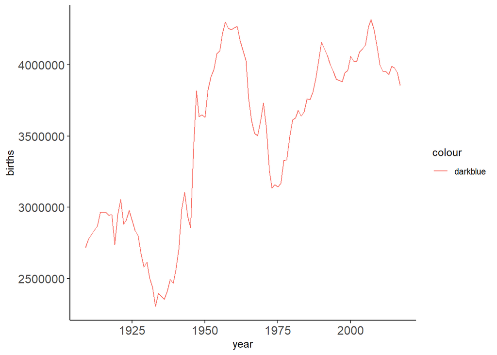

   ```r
   ggplot(data = births) +
     geom_line(aes(x = year, y = births, col = "darkblue")) + theme(plot.subtitle = element_text(vjust = 1),
   plot.caption = element_text(vjust = 1),
   axis.line = element_line(linetype = "solid"),
   panel.grid.major = element_line(linetype = "blank"),
   axis.text = element_text(size = 12),
   axis.text.x = element_text(size = 12),
   panel.background = element_rect(fill = NA,
       linetype = "solid"), legend.key = element_rect(fill = "white"),
   legend.background = element_rect(fill = NA,
       linetype = "solid"))
   ```

   Ahora bien, para obtener la década con menor nacimientos consideramos el siguiente código:

   ```r
     births %>%
   filter(year >= 1910) %>%
   mutate(decade = floor(year/10)*10) %>%
   group_by(decade) %>%
   summarise(nacimientos = sum(births)) %>%
   filter(nacimientos == min(nacimientos))
   ```

   ```
   ## # A tibble: 1 x 2
   ##   decade nacimientos
   ##    <dbl>       <int>
   ## 1   1930    24374000
   ```

   Por lo tanto, la década con menos nacimientos es la década del 30.

# Problema 2

Considere ahora la tabla `babynames` del paquete `babynames`.

1. Realice el proceso necesario para obtener la misma estructura en cuanto a **columnas** que la tabla `births`, esto es, generar una nueva tabla que nos entregue el número de nacimientos por año.
2. Genere un data frame partiendo de la tabla `babynames` que contenga los nacimientos de las personas de género femenino con el nombre **Nala, Ariel** y **Elsa** desde los años 1980.
3. Con el data frame obtenido en la parte anterior, genere un gráfico que contenga la información de los nacimientos por año de cada uno de los nombres mencionados y mencionte una hipótesis/suposición al respecto de lo observado. *Hint:* Use `face_wrap(~ name, scales = "free_y")`.

## Solución

1. El siguiente código realiza lo pedido:

   ```r
   babynames %>%
   group_by(year) %>%
   summarise(births = n() ) -> births2
     head(births2)
   ```

   ```
   ## # A tibble: 6 x 2
   ##    year births
   ##   <dbl>  <int>
   ## 1  1880   2000
   ## 2  1881   1935
   ## 3  1882   2127
   ## 4  1883   2084
   ## 5  1884   2297
   ## 6  1885   2294
   ```

2. El siguiente código realiza lo pedido:

   ```r
   babynames %>%
   filter(sex == "F", year >= 1980, name %in% c("Nala","Ariel","Elsa")) %>%
   arrange(name) -> births3
     head(births3)
   ```

   ```
   ## # A tibble: 6 x 5
   ##    year sex   name      n     prop
   ##   <dbl> <chr> <chr> <int>    <dbl>
   ## 1  1980 F     Ariel   181 0.000102
   ## 2  1981 F     Ariel   228 0.000128
   ## 3  1982 F     Ariel   584 0.000322
   ## 4  1983 F     Ariel   650 0.000363
   ## 5  1984 F     Ariel   636 0.000353
   ## 6  1985 F     Ariel   600 0.000325
   ```

3. El siguiente código resulta en el gráfico pedido

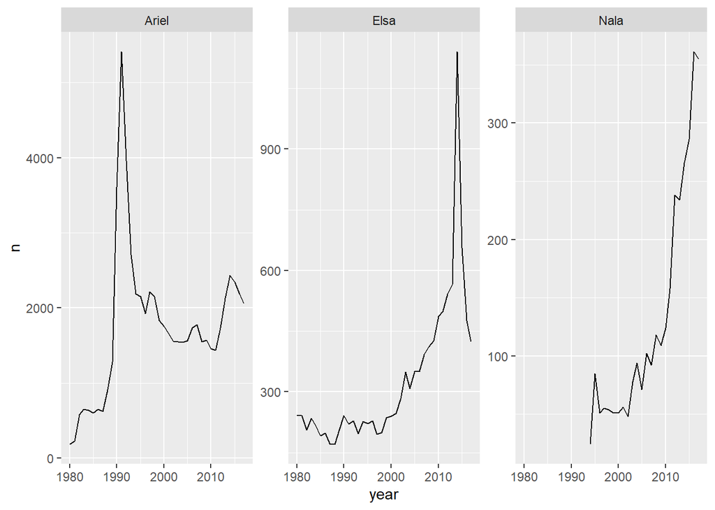

   ```r
   ggplot(data = births3) +
      geom_line(aes(x = year, y = n)) +
      facet_wrap( ~ name, ncol = 3, nrow = 1, scales = "free_y")
   ```

# Problema 3

1. Utilizando las tablas `airports` y `flights` del paquete `nycflights13` obtenga una tabla que contenga conteos de vuelos según su destino `dest` además de la longitud y latitud del aeropuerto(de destino).
2. Apoyándose del siguiente gráfico:

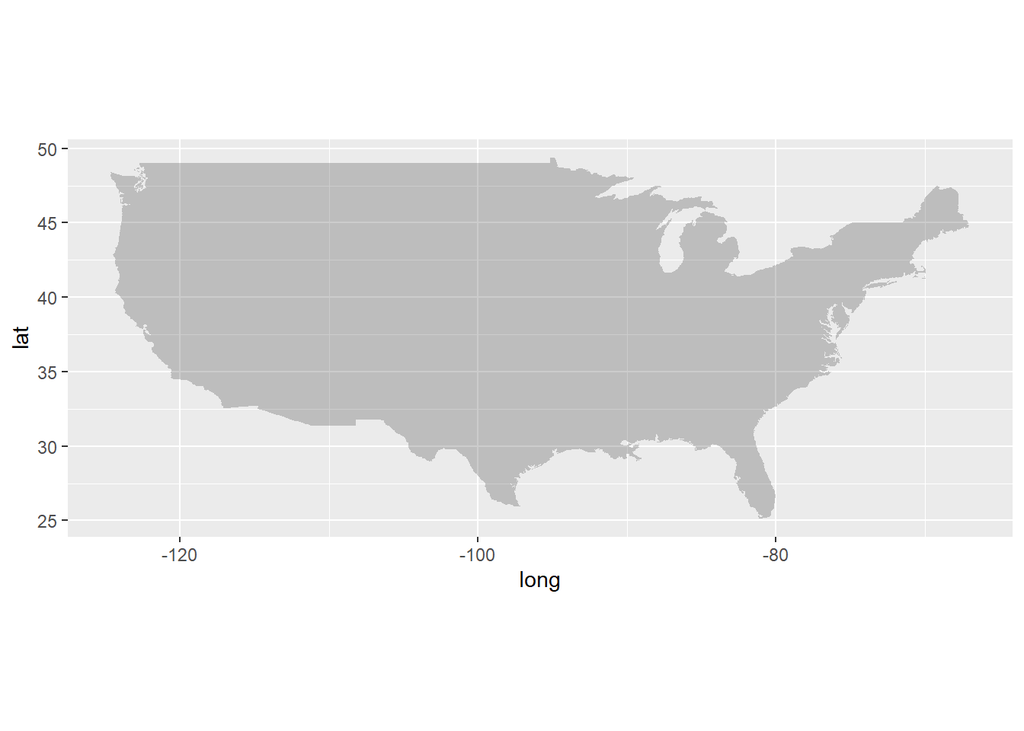

   ```r
   library(maps)
   us <- map_data("state")

   ggmap <- ggplot() +
     geom_polygon(data = us, aes(long, lat, group = group), alpha = 0.25) +
     coord_fixed() # esto es para mantener la razón 1:1

   ggmap
   ```

   1. Agregue una capa de puntos ubicando los aeropuertos obtenidos de la pregunta anterior y usando además: `aes(size = la_cantidad_de_vuelos_a_dicho_aeropuerto)`.
   2. A la izquierda del gráfico anterior se observan 2 puntos. Genere el/los pasos necesarios para seleccionarlos usando la tabla resultante de la pregunta 5 para identificar los nombres de dichos aeropuertos y responda: ¿Donde están? ¿Qué gracias tienen?

## Solución

1. El siguiente código obtiene lo pedido:

   ```r
     flights %>%
   left_join(airports, by = c("dest" = "faa")) %>%
   group_by(name) %>%
   summarise(nvuelos = n()) %>%
   left_join(airports, by = "name") %>%
   select(name,lat,lon,nvuelos) -> airports2
     head(airports2)
   ```

   ```
   ## # A tibble: 6 x 4
   ##   name                                lat    lon nvuelos
   ##   <chr>                             <dbl>  <dbl>   <int>
   ## 1 Akron Canton Regional Airport      40.9  -81.4     864
   ## 2 Albany Intl                        42.7  -73.8     439
   ## 3 Albuquerque International Sunport  35.0 -107.      254
   ## 4 Asheville Regional Airport         35.4  -82.5     275
   ## 5 Austin Bergstrom Intl              30.2  -97.7    2439
   ## 6 Baltimore Washington Intl          39.2  -76.7    1781
   ```

2. El siguiente código obtiene lo pedido:

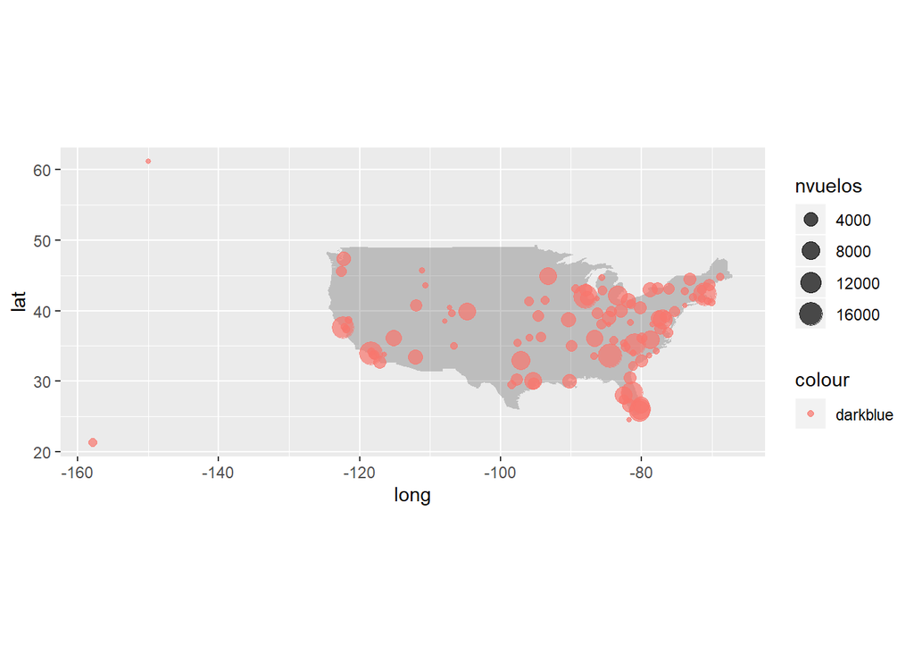

   ```r
   ggmap <- ggplot() +
   geom_polygon(data = us, aes(long, lat, group = group), alpha = 0.25) +
   coord_fixed()

     ggmap +
   geom_point(data = airports2,
              aes(x = lon, y = lat, size = nvuelos, color = "darkblue"),
              alpha = 0.7)
   ```

   ```r
     airports2 %>%
   filter(lon < -130)
   ```

   ```
   ## # A tibble: 2 x 4
   ##   name                         lat   lon nvuelos
   ##   <chr>                      <dbl> <dbl>   <int>
   ## 1 Honolulu Intl               21.3 -158.     707
   ## 2 Ted Stevens Anchorage Intl  61.2 -150.       8
   ```